# Notebook

**Von Einem zu Vielen - Einführung in Matrizen**

Dr. Matthias Hölzl

## Das Problem: Viele Vorhersagen

Bisher: Eine Vorhersage nach der anderen

- Ein Feature-Vektor → Eine Vorhersage

Realität: Wir brauchen oft viele Vorhersagen

- 1000 Häuser bewerten
- Alle Testdaten vorhersagen

```python
import numpy as np
import time
```

Hauspreismodell

```python
coefficients = np.array([0.5, 25.0, 20.0, -1.5, 30.0])
intercept = 100.0
```

Drei Häuser zum Vorhersagen

```python
house1 = np.array([100, 3, 1, 10, 0])
house2 = np.array([180, 4, 3, 2, 1])
house3 = np.array([120, 2, 2, 20, 1])
```

## Lösung 1: Schleife

Wir könnten eine Schleife verwenden:

```python
houses = [house1, house2, house3]
predictions = []
```

```python
for house in houses:
    pred = np.dot(house, coefficients) + intercept
    predictions.append(pred)
```

```python
predictions
```

```
[np.float64(230.0), np.float64(377.0), np.float64(250.0)]
```

## Problem mit Schleifen

- Langsam bei vielen Daten
- Verliert einen Teil von NumPy's Geschwindigkeitsvorteil
- Nicht elegant

Es gibt einen besseren Weg!

## Matrizen: Tabellen von Zahlen

Eine Matrix ist ein 2D-Array:

- Zeilen und Spalten
- Wie eine Tabelle oder Spreadsheet
- Perfekt für mehrere Datenpunkte

## Unsere Häuser als Matrix

- Stapele Häuser zu einer Matrix
- Jede Zeile ist ein Haus
- Jede Spalte ist ein Feature

```python
houses_matrix = np.array(
    [
        [100, 3, 1, 10, 0],  # House 1
        [180, 4, 3, 2, 1],  # House 2
        [120, 2, 2, 20, 1],  # House 3
    ]
)
```

```python
houses_matrix
```

```
array([[100,   3,   1,  10,   0],
       [180,   4,   3,   2,   1],
       [120,   2,   2,  20,   1]])
```

```python
houses_matrix.shape
```

```
(3, 5)
```

Anzahl der Zeilen (Häuser)

```python
houses_matrix.shape[0]
```

```
3
```

Anzahl der Spalten (Features)

```python
houses_matrix.shape[1]  # number of columns (features)
```

```
5
```

## Matrix visualisieren

```python
import matplotlib.pyplot as plt
```

```python
def plot_matrix(matrix):
    fig, ax = plt.subplots(figsize=(8, 4))
    im = ax.imshow(houses_matrix, cmap="YlOrRd", aspect="auto", vmax=1000)
    feature_names = ["Size", "Beds", "Baths", "Age", "Garage"]
    ax.set_xticks(range(5))
    ax.set_xticklabels(feature_names)
    ax.set_yticks(range(3))
    ax.set_yticklabels([f"House {i+1}" for i in range(3)])

    for i in range(3):
        for j in range(5):
            text = ax.text(
                j, i, houses_matrix[i, j], ha="center", va="center", color="black"
            )

    ax.set_title("Houses Matrix")
    plt.tight_layout()
    plt.show()
```

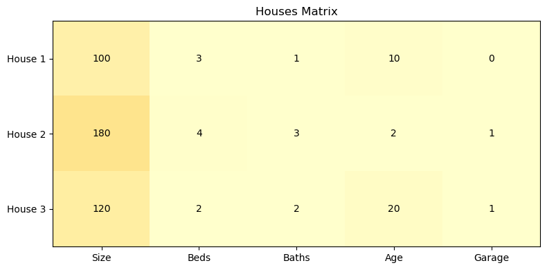

```python
plot_matrix(houses_matrix)
```

## Auf Matrix-Elemente zugreifen

- Matrizen haben zwei Indizes: [Zeile, Spalte]
- Wir können einzelne Elemente, ganze Zeilen oder Spalten auswählen

### Zugriff auf spezifische Elemente

Haus 1, Größe

```python
houses_matrix[0, 0]
```

```
np.int64(100)
```

Haus 2, Schlafzimmer

```python
houses_matrix[1, 1]
```

```
np.int64(4)
```

Haus 3, Garage

```python
houses_matrix[2, 4]
```

```
np.int64(1)
```

### Zugriff auf ganze Zeilen (Häuser)

Features von Haus 1

```python
houses_matrix[0]
```

```
array([100,   3,   1,  10,   0])
```

Features von Haus 2

```python
houses_matrix[1]
```

```
array([180,   4,   3,   2,   1])
```

Zugriff auf ganze Spalten (Features)

Größe aller Häuser

```python
houses_matrix[:, 0]
```

```
array([100, 180, 120])
```

Schlafzimmer aller Häuser

```python
houses_matrix[:, 1]
```

```
array([3, 4, 2])
```

### Änderung von Zeilen oder Spalten

- Wir können ganze Zeilen oder Spalten in der Matrix ändern!
- Diese Änderungen sind destruktiv (ändern die Originalmatrix)

```python
matrix = np.array([[1, 2, 3], [4, 5, 6]])
```

```python
matrix
```

```
array([[1, 2, 3],
       [4, 5, 6]])
```

```python
matrix[0] = [10, 20, 30]  # Change first row
```

```python
matrix
```

```
array([[10, 20, 30],
       [ 4,  5,  6]])
```

```python
matrix[:, 1] = [99, 88]  # Change second column
```

```python
matrix
```

```
array([[10, 99, 30],
       [ 4, 88,  6]])
```

```python
matrix = np.array([[1, 2, 3], [4, 5, 6]])  # Reset
```

```python
matrix[0] = matrix[0] + 10  # Add 10 to first row
```

```python
matrix[1] = matrix[1] + 20  # Add 20 to second row
```

```python
matrix
```

```
array([[11, 12, 13],
       [24, 25, 26]])
```

## Matrix-Vektor-Multiplikation

Die Magie: Wir können eine Matrix mit einem Vektor multiplizieren!

- Jede Zeile wird mit dem Vektor skalar-multipliziert
- Ergebnis: Ein Vektor mit allen Vorhersagen

## Visualisierung der Matrix-Vektor-Multiplikation

Einfaches Beispiel zur Visualisierung

```python
simple_matrix = np.array([[1, 2], [3, 4], [5, 6]])
```

```python
simple_vector = np.array([10, 20])
```

```python
simple_matrix
```

```
array([[1, 2],
       [3, 4],
       [5, 6]])
```

```python
simple_vector
```

```
array([10, 20])
```

Manuelle Berechnung

```python
print("\nManual calculation:")
for i, row in enumerate(simple_matrix):
    dot_product = np.dot(row, simple_vector)
    print(
        f"Row {i}: {row} · {simple_vector} = {row[0]}×{simple_vector[0]} + {row[1]}×{simple_vector[1]} = {dot_product}"
    )
```

```
Manual calculation:
Row 0: [1 2] · [10 20] = 1×10 + 2×20 = 50
Row 1: [3 4] · [10 20] = 3×10 + 4×20 = 110
Row 2: [5 6] · [10 20] = 5×10 + 6×20 = 170
```

NumPy-Berechnung

```python
simple_matrix @ simple_vector
```

```
array([ 50, 110, 170])
```

## Batch-Vorhersagen mit Matrix-Multiplikation

- Wir können mehrere Vektoren in eine Matrix packen
- Dann können wir alle Vorhersagen auf einmal berechnen!

```python
houses_matrix
```

```
array([[100,   3,   1,  10,   0],
       [180,   4,   3,   2,   1],
       [120,   2,   2,  20,   1]])
```

```python
coefficients
```

```
array([ 0.5, 25. , 20. , -1.5, 30. ])
```

```python
houses_matrix @ coefficients
```

```
array([130., 277., 150.])
```

```python
predictions_vector = houses_matrix @ coefficients + intercept
```

```python
predictions_vector
```

```
array([230., 377., 250.])
```

```python
print("All predictions at once:")
for i, pred in enumerate(predictions_vector):
    print(f"House {i+1}: {pred:.1f}k€")
```

```
All predictions at once:
House 1: 230.0k€
House 2: 377.0k€
House 3: 250.0k€
```

Vergleiche mit Schleifen-Ergebnissen

```python
print("\nSame as our loop? ", np.allclose(predictions, predictions_vector))
```

```
Same as our loop?  True
```

## Geschwindigkeitsvergleich

Erstelle viele Häuser

```python
n_houses = 10000
n_features = 5
```

Zufällige Hausdaten

```python
large_houses_matrix = np.random.rand(n_houses, n_features) * 100
large_coefficients = np.random.randn(n_features)
```

Zeitmessung für Schleifenversion

```python
start = time.time()
predictions_loop = []
for i in range(n_houses):
    pred = np.dot(large_houses_matrix[i], large_coefficients) + intercept
    predictions_loop.append(pred)
time_loop = time.time() - start
```

Zeitmessung für Matrix-Version

```python
start = time.time()
predictions_matrix = large_houses_matrix @ large_coefficients + intercept
time_matrix = time.time() - start
```

```python
print(f"Predicting for {n_houses} houses:")
print(f"Loop version: {time_loop:.4f} seconds")
print(f"Matrix version: {time_matrix:.4f} seconds")
print(f"Matrix is {time_loop/time_matrix:.1f}x faster!")
```

```
Predicting for 10000 houses:
Loop version: 0.0121 seconds
Matrix version: 0.0005 seconds
Matrix is 22.3x faster!
```

## Weitere Matrix-Operationen

## Transponieren

Zeilen und Spalten vertauschen:

```python
matrix = np.array([[1, 2, 3], [4, 5, 6]])
```

```python
matrix
```

```
array([[1, 2, 3],
       [4, 5, 6]])
```

```python
matrix.shape
```

```
(2, 3)
```

```python
transposed = matrix.T  # oder np.transpose(matrix)
```

```python
transposed
```

```
array([[1, 4],
       [2, 5],
       [3, 6]])
```

```python
transposed.shape
```

```
(3, 2)
```

## Elementweise Operationen

```python
matrix = np.array([[10, 20, 30], [40, 50, 60]])
```

Addieren/Subtrahieren/Multiplizieren mit Skalar

```python
matrix
```

```
array([[10, 20, 30],
       [40, 50, 60]])
```

```python
matrix + 5
```

```
array([[15, 25, 35],
       [45, 55, 65]])
```

```python
matrix * 2
```

```
array([[ 20,  40,  60],
       [ 80, 100, 120]])
```

```python
matrix / 10
```

```
array([[1., 2., 3.],
       [4., 5., 6.]])
```

## Methoden auf Matrizen

- Die uns bekannten NumPy-Methoden funktionieren auch auf Matrizen
  - `.shape` für Dimensionen
  - `.sum()` für Summen
  - `.mean()` für Mittelwerte
  - `.std()` für Standardabweichungen
  - `.T` für Transponieren
  - `.copy()` für Kopien

```python
matrix = np.array([[1, 2, 3], [4, 5, 6]])
```

Summe aller Elemente

```python
matrix.sum()
```

```
np.int64(21)
```

Mittelwert aller Elemente

```python
matrix.mean()
```

```
np.float64(3.5)
```

Standardabweichung aller Elemente (Wie weit streuen die Werte?)

```python
matrix.std()
```

```
np.float64(1.707825127659933)
```

Transponieren der Matrix

```python
matrix.T
```

```
array([[1, 4],
       [2, 5],
       [3, 6]])
```

```python
matrix.transpose()
```

```
array([[1, 4],
       [2, 5],
       [3, 6]])
```

Kopie der Matrix

```python
matrix_copy = matrix.copy()
```

```python
matrix_copy
```

```
array([[1, 2, 3],
       [4, 5, 6]])
```

```python
matrix_copy[0, 0] = 999
```

```python
matrix_copy
```

```
array([[999,   2,   3],
       [  4,   5,   6]])
```

```python
matrix  # Original bleibt unverändert
```

```
array([[1, 2, 3],
       [4, 5, 6]])
```

- Viele Operationen können entlang der Zeilen oder Spalten ausgeführt werden:
  - .sum(axis=0) für Spaltensummen
  - .sum(axis=1) für Zeilensummen

```python
matrix = np.array([[1, 2, 3], [4, 5, 6]])
```

```python
matrix
```

```
array([[1, 2, 3],
       [4, 5, 6]])
```

Spaltensummen

```python
matrix.sum(axis=0)
```

```
array([5, 7, 9])
```

Zeilensummen

```python
matrix.sum(axis=1)
```

```
array([ 6, 15])
```

Spaltenmittelwert

```python
matrix.mean(axis=0)
```

```
array([2.5, 3.5, 4.5])
```

Zeilenmittelwert

```python
matrix.mean(axis=1)
```

```
array([2., 5.])
```

## Zusammenfassung

- Matrizen sind 2D-Arrays (Tabellen von Zahlen)
- Jede Zeile = ein Datenpunkt
- Jede Spalte = ein Feature
- Matrix @ Vektor = Alle Vorhersagen auf einmal!
- Viel schneller als Schleifen

## Nächste Schritte

- Wir können jetzt effizient viele Vorhersagen machen
- Zeit, unser eigenes Regressionsmodell zu bauen!
- Nächstes Thema: Eine komplette LinearRegression-Klasse
- Mit fit() und predict() wie Scikit-Learn!

## Workshop: Studentennoten-Vorhersage

Wir werden folgendes Modell zur Vorhersage von Abschlussnoten verwenden:

```python
feature_names = ["Homework Average", "Midterm Score", "Attendance", "Study Hours"]
```

```python
grade_coefficients = np.array([0.2, 0.4, 0.2, 0.05])
grade_intercept = 10.0
```

```python
print("Grade Prediction Model:")
for name, coef in zip(feature_names, grade_coefficients):
    print(f"{name:17}: {coef}")
print(f"{'Base':17}: {grade_intercept}")
```

```
Grade Prediction Model:
Homework Average : 0.2
Midterm Score    : 0.4
Attendance       : 0.2
Study Hours      : 0.05
Base             : 10.0
```

### Aufgabe 1: Matrix erstellen

Erstellen Sie eine Matrix für diese 5 Studenten:

```python
student_data = [
    [85, 78, 90, 20],  # Student A
    [92, 88, 95, 30],  # Student B
    [70, 65, 75, 10],  # Student C
    [88, 82, 85, 25],  # Student D
    [75, 70, 60, 15],  # Student E
]
```

```python
student_names = ["Alice", "Bob", "Charlie", "Diana", "Eve"]
```

```python
students_matrix = np.array(student_data)
```

```python
students_matrix
```

```
array([[85, 78, 90, 20],
       [92, 88, 95, 30],
       [70, 65, 75, 10],
       [88, 82, 85, 25],
       [75, 70, 60, 15]])
```

### Aufgabe 2: Batch-Vorhersagen

Berechnen Sie alle Abschlussnoten auf einmal:

```python
final_grades = students_matrix @ grade_coefficients + grade_intercept
```

```python
final_grades
```

```
array([77.2 , 84.1 , 65.5 , 78.65, 65.75])
```

```python
print("Final Grade Predictions:")
print("-" * 30)
for name, grade in zip(student_names, final_grades):
    print(f"{name:10}: {grade:.1f}")
```

```
Final Grade Predictions:
------------------------------
Alice     : 77.2
Bob       : 84.1
Charlie   : 65.5
Diana     : 78.7
Eve       : 65.8
```

Finde besten und schlechtesten Studenten

```python
best_idx = final_grades.argmax()
worst_idx = final_grades.argmin()
print(f"\nBest student: {student_names[best_idx]} ({final_grades[best_idx]:.1f})")
print(f"Worst student: {student_names[worst_idx]} ({final_grades[worst_idx]:.1f})")
```

```
Best student: Bob (84.1)
Worst student: Charlie (65.5)
```

### Aufgabe 3: Feature-Statistiken

Berechnen Sie Durchschnitt und Standardabweichung für jedes Feature:

```python
feature_means = students_matrix.mean(axis=0)  # axis=0 means along rows
feature_stds = students_matrix.std(axis=0)
```

```python
print("Feature Statistics:")
print("-" * 40)
for name, mean, std in zip(feature_names, feature_means, feature_stds):
    print(f"{name:12}: μ={mean:.1f}, σ={std:.1f}")
```

```
Feature Statistics:
----------------------------------------
Homework Average: μ=82.0, σ=8.2
Midterm Score: μ=76.6, σ=8.2
Attendance  : μ=81.0, σ=12.4
Study Hours : μ=20.0, σ=7.1
```

Welches Feature variiert am meisten?

```python
most_variable_idx = feature_stds.argmax()
print(
    f"\nMost variable feature: {feature_names[most_variable_idx]} (σ={feature_stds[most_variable_idx]:.1f})"
)
```

```
Most variable feature: Attendance (σ=12.4)
```

### Aufgabe 4: Was-wäre-wenn-Analyse

Was passiert mit den Noten, wenn alle Studenten:

1. 10 Punkte mehr bei der Zwischenprüfung hätten?
2. Ihre Anwesenheit um 10% verbessern?

Szenario 1: +10 Punkte bei Zwischenprüfung

```python
students_scenario1 = students_matrix.copy()
students_scenario1[:, 1] += 10  # Column 1 is midterm
grades_scenario1 = students_scenario1 @ grade_coefficients + grade_intercept
```

```python
print("Scenario 1: +10 points on midterm")
for name, original, new in zip(student_names, final_grades, grades_scenario1):
    improvement = new - original
    print(f"{name:10}: {original:.1f} → {new:.1f} (+{improvement:.1f})")
```

```
Scenario 1: +10 points on midterm
Alice     : 77.2 → 81.2 (+4.0)
Bob       : 84.1 → 88.1 (+4.0)
Charlie   : 65.5 → 69.5 (+4.0)
Diana     : 78.7 → 82.7 (+4.0)
Eve       : 65.8 → 69.8 (+4.0)
```

Szenario 2: +10% Anwesenheit

```python
students_scenario2 = students_matrix.copy()
students_scenario2[:, 2] = np.minimum(100, students_scenario2[:, 2] + 10)  # Cap at 100
grades_scenario2 = students_scenario2 @ grade_coefficients + grade_intercept
```

```python
print("\nScenario 2: +10% attendance")
for name, original, new in zip(student_names, final_grades, grades_scenario2):
    improvement = new - original
    print(f"{name:10}: {original:.1f} → {new:.1f} (+{improvement:.1f})")
```

```
Scenario 2: +10% attendance
Alice     : 77.2 → 79.2 (+2.0)
Bob       : 84.1 → 85.1 (+1.0)
Charlie   : 65.5 → 67.5 (+2.0)
Diana     : 78.7 → 80.7 (+2.0)
Eve       : 65.8 → 67.8 (+2.0)
```

Welche Verbesserung ist besser?

```python
avg_improvement_midterm = (grades_scenario1 - final_grades).mean()
avg_improvement_attendance = (grades_scenario2 - final_grades).mean()
```

```python
print(f"\nAverage improvement from midterm: {avg_improvement_midterm:.1f}")
print(f"Average improvement from attendance: {avg_improvement_attendance:.1f}")
```

```
Average improvement from midterm: 4.0
Average improvement from attendance: 1.8
```

### Aufgabe 5: Batch-Vorhersagefunktion

```python
def predict_batch(features_matrix, coefficients, intercept):
    """
    Make predictions for multiple samples.

    Parameters:
    - features_matrix: 2D array, each row is one sample
    - coefficients: 1D array of model coefficients
    - intercept: scalar intercept

    Returns:
    - predictions: 1D array of predictions
    """
    # Your solution here
    pass
```

```python
def predict_batch(features_matrix, coefficients, intercept):
    """
    Make predictions for multiple samples.

    Parameters:
    - features_matrix: 2D array, each row is one sample
    - coefficients: 1D array of model coefficients
    - intercept: scalar intercept

    Returns:
    - predictions: 1D array of predictions
    """
    features_matrix = np.array(features_matrix)
    coefficients = np.array(coefficients)

    # Check dimensions
    if features_matrix.ndim != 2:
        raise ValueError("Features must be a 2D matrix")

    if features_matrix.shape[1] != len(coefficients):
        raise ValueError(
            f"Feature count mismatch: matrix has {features_matrix.shape[1]} features, "
            f"but {len(coefficients)} coefficients provided"
        )

    return features_matrix @ coefficients + intercept
```

Testen Sie die Funktion

```python
test_predictions = predict_batch(students_matrix, grade_coefficients, grade_intercept)
print("Test predictions:", test_predictions)
print("Match our earlier results?", np.allclose(test_predictions, final_grades))
```

```
Test predictions: [77.2  84.1  65.5  78.65 65.75]
Match our earlier results? True
```